# Iris

##### Exploratory Data Analysis

###### 1. Introduction

The Iris flower data set consists of flower samples from three species of Iris plant (Iris setosa, Iris virginica and Iris versicolor), showing measures in centimeters of length and width of each type of flower's sepals and petals example.

[figure not shown]

This report presents an exploratory data analysis (EDA) of the Iris data set, which is a statistical approach to analyzing data sets whose the main purpose is to summarize their characteristics, usually in form of tables or visualizations.

The report is organized into five parts, first, this introduction, second, loading libraries and data set, third, the EDA itself, divided into tables and visualizations, fourth, correlation analysis, and fifth, conclusion.

This is a project made in and Python with JupyterLab Notebook.

###### 2. Load required libraries and dataset

```python
# Load required libraries
import numpy as np
import pandas as pd
import matplotlib.pyplot as plt
import seaborn as sns
```

The packages required for this project are numpy, pandas, matplotlib and seaborn.

```python
# Load dataset
iris = pd.read_csv('Iris.csv')
```

The data set is a comma separated value file type (.csv) with name Iris.

###### 3. Exploratory Data Analysis (EDA)

###### 3.1 Tables

###### 3.1.1 Print dataset

```python
# Print dataset
iris
```

|  | Id | SepalLengthCm | SepalWidthCm | PetalLengthCm | PetalWidthCm | Species |
| --- | --- | --- | --- | --- | --- | --- |
| 0 | 1 | 5.1 | 3.5 | 1.4 | 0.2 | Iris-setosa |
| 1 | 2 | 4.9 | 3.0 | 1.4 | 0.2 | Iris-setosa |
| 2 | 3 | 4.7 | 3.2 | 1.3 | 0.2 | Iris-setosa |
| 3 | 4 | 4.6 | 3.1 | 1.5 | 0.2 | Iris-setosa |
| 4 | 5 | 5.0 | 3.6 | 1.4 | 0.2 | Iris-setosa |
| ... | ... | ... | ... | ... | ... | ... |
| 145 | 146 | 6.7 | 3.0 | 5.2 | 2.3 | Iris-virginica |
| 146 | 147 | 6.3 | 2.5 | 5.0 | 1.9 | Iris-virginica |
| 147 | 148 | 6.5 | 3.0 | 5.2 | 2.0 | Iris-virginica |
| 148 | 149 | 6.2 | 3.4 | 5.4 | 2.3 | Iris-virginica |
| 149 | 150 | 5.9 | 3.0 | 5.1 | 1.8 | Iris-virginica |

150 rows × 6 columns

The Iris flower data set has 150 rows and 6 columns.

###### 3.1.2 Get information of the dataset

```python
# Get information of the dataset
iris.info()
```

```
<class 'pandas.core.frame.DataFrame'>
RangeIndex: 150 entries, 0 to 149
Data columns (total 6 columns):
 #   Column         Non-Null Count  Dtype
---  ------         --------------  -----
 0   Id             150 non-null    int64
 1   SepalLengthCm  150 non-null    float64
 2   SepalWidthCm   150 non-null    float64
 3   PetalLengthCm  150 non-null    float64
 4   PetalWidthCm   150 non-null    float64
 5   Species        150 non-null    object
dtypes: float64(4), int64(1), object(1)
memory usage: 7.2+ KB
```

From the six columns, four are the variables, Sepal Length, Sepal Width, Petal Length and Petal Wigth, and one is the response, Species. There are 150 no null values per each variable and response. The variables data type are float and the response data type is object.

###### 3.1.3 Check species

```python
# Check species
iris.groupby('Species').size()
```

```
Species
Iris-setosa        50
Iris-versicolor    50
Iris-virginica     50
dtype: int64
```

The response has three classes, Iris-setosa, Iris-versicolor and Iris-virginica, each one with 50 examples.

###### 3.1.4 Check missing values in the dataset

```python
# Check missing values in the dataset
iris.isnull().sum().sum()
```

```
0
```

There is no null value.

###### 3.1.5 Perform statistical summary on the dataset

```python
# Perform statistical summary on the dataset
iris.describe()
```

|  | Id | SepalLengthCm | SepalWidthCm | PetalLengthCm | PetalWidthCm |
| --- | --- | --- | --- | --- | --- |
| count | 150.000000 | 150.000000 | 150.000000 | 150.000000 | 150.000000 |
| mean | 75.500000 | 5.843333 | 3.054000 | 3.758667 | 1.198667 |
| std | 43.445368 | 0.828066 | 0.433594 | 1.764420 | 0.763161 |
| min | 1.000000 | 4.300000 | 2.000000 | 1.000000 | 0.100000 |
| 25% | 38.250000 | 5.100000 | 2.800000 | 1.600000 | 0.300000 |
| 50% | 75.500000 | 5.800000 | 3.000000 | 4.350000 | 1.300000 |
| 75% | 112.750000 | 6.400000 | 3.300000 | 5.100000 | 1.800000 |
| max | 150.000000 | 7.900000 | 4.400000 | 6.900000 | 2.500000 |

The table shows count, mean, standar deviation, minimun and maximun values, and 25%, 50% and 75% percentiles of variables.

###### 3.1.6 Perform statistical summary by Species

```python
# Perform statistical summary by Species
L = ['SepalLengthCm', 'SepalWidthCm', 'PetalLengthCm', 'PetalWidthCm']
iris.groupby('Species')[L].describe().stack()
```

| Species |  | SepalLengthCm | SepalWidthCm | PetalLengthCm | PetalWidthCm |
| --- | --- | --- | --- | --- | --- |
| Iris-setosa | count | 50.000000 | 50.000000 | 50.000000 | 50.000000 |
|  | mean | 5.006000 | 3.418000 | 1.464000 | 0.244000 |
|  | std | 0.352490 | 0.381024 | 0.173511 | 0.107210 |
|  | min | 4.300000 | 2.300000 | 1.000000 | 0.100000 |
|  | 25% | 4.800000 | 3.125000 | 1.400000 | 0.200000 |
|  | 50% | 5.000000 | 3.400000 | 1.500000 | 0.200000 |
|  | 75% | 5.200000 | 3.675000 | 1.575000 | 0.300000 |
|  | max | 5.800000 | 4.400000 | 1.900000 | 0.600000 |
| Iris-versicolor | count | 50.000000 | 50.000000 | 50.000000 | 50.000000 |
|  | mean | 5.936000 | 2.770000 | 4.260000 | 1.326000 |
|  | std | 0.516171 | 0.313798 | 0.469911 | 0.197753 |
|  | min | 4.900000 | 2.000000 | 3.000000 | 1.000000 |
|  | 25% | 5.600000 | 2.525000 | 4.000000 | 1.200000 |
|  | 50% | 5.900000 | 2.800000 | 4.350000 | 1.300000 |
|  | 75% | 6.300000 | 3.000000 | 4.600000 | 1.500000 |
|  | max | 7.000000 | 3.400000 | 5.100000 | 1.800000 |
| Iris-virginica | count | 50.000000 | 50.000000 | 50.000000 | 50.000000 |
|  | mean | 6.588000 | 2.974000 | 5.552000 | 2.026000 |
|  | std | 0.635880 | 0.322497 | 0.551895 | 0.274650 |
|  | min | 4.900000 | 2.200000 | 4.500000 | 1.400000 |
|  | 25% | 6.225000 | 2.800000 | 5.100000 | 1.800000 |
|  | 50% | 6.500000 | 3.000000 | 5.550000 | 2.000000 |
|  | 75% | 6.900000 | 3.175000 | 5.875000 | 2.300000 |
|  | max | 7.900000 | 3.800000 | 6.900000 | 2.500000 |

The table shows count, mean, standar deviation, minimun and maximun values, and 25%, 50% and 75% percentiles of each response class.

###### 3.2 Visualizations

###### 3.2.1 Histograms

###### 3.2.1.1 Histogram of features with matplotlib

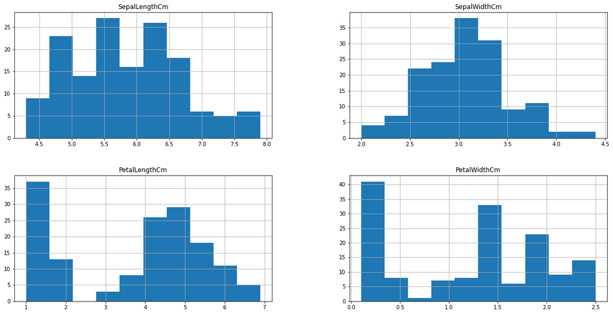

```python
# Histogram of features with matplotlib
iris[L].hist(figsize = (20, 10));
```

Matplotlib histograms of features (variables), Sepal Length, Sepal Width, Petal Length and Petal Width.

###### 3.2.1.2 Histogram of features with seaborn

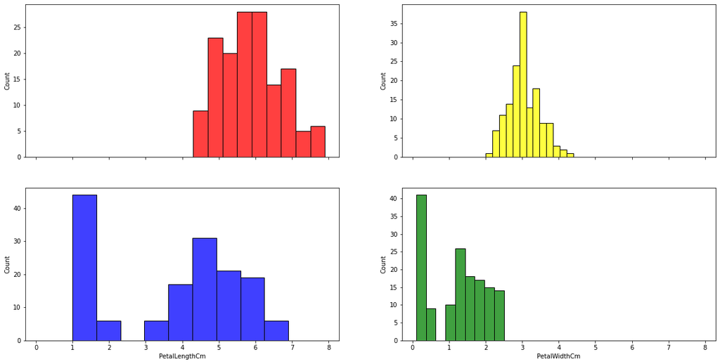

```python
# Histogram of features with seaborn
f, axes = plt.subplots(2, 2, figsize=(20, 10), sharex=True)
sns.histplot(iris["SepalLengthCm"], color="red", ax=axes[0, 0])
sns.histplot(iris["SepalWidthCm"], color="yellow", ax=axes[0, 1])
sns.histplot(iris["PetalLengthCm"], color="blue", ax=axes[1, 0])
sns.histplot(iris["PetalWidthCm"], color="green", ax=axes[1, 1]);
```

Seaborn histograms of features (variables), Sepal Length, Sepal Width, Petal Length and Petal Width.

###### 3.2.1.3 Histogram of each feature per target class

```python
# Create a unique list for target
unique_list = iris['Species'].unique()
unique_list
```

```
array(['Iris-setosa', 'Iris-versicolor', 'Iris-virginica'], dtype=object)
```

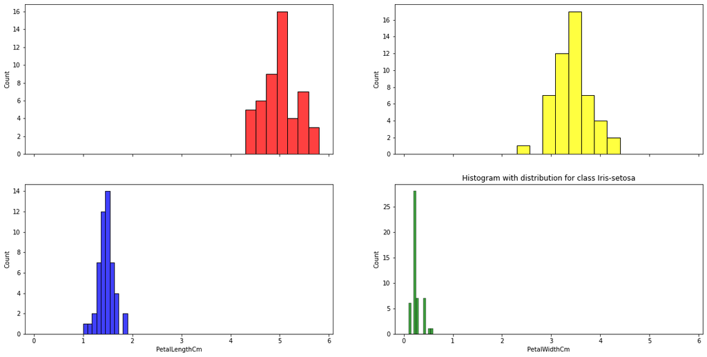

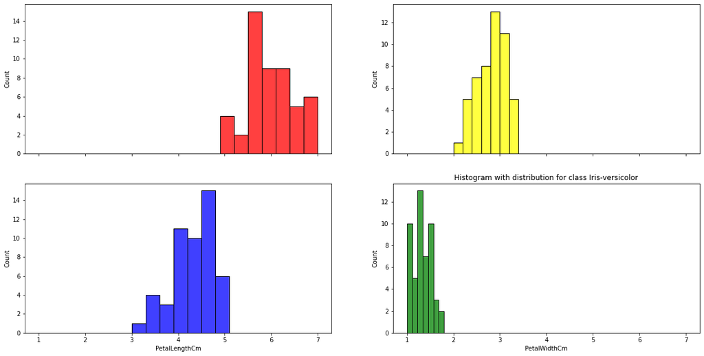

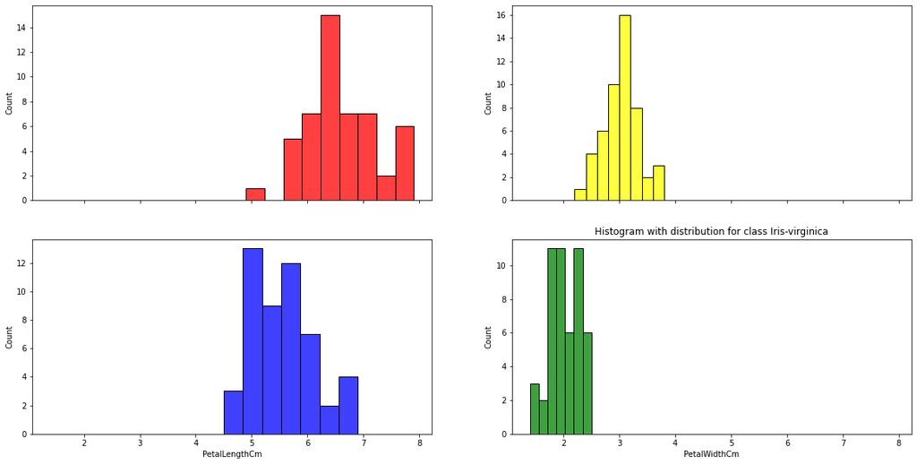

```python
# Histogram of each feature per target class
for i in unique_list:
    iris_class = iris[iris['Species'] == i]
    f, axes = plt.subplots(2, 2, figsize=(20, 10), sharex=True)
    plt.title('Histogram with distribution for class {}'.format(i))
    sns.histplot(iris_class["SepalLengthCm"], color="red", ax=axes[0, 0])
    sns.histplot(iris_class["SepalWidthCm"], color="yellow", ax=axes[0, 1])
    sns.histplot(iris_class["PetalLengthCm"], color="blue", ax=axes[1, 0])
    sns.histplot(iris_class["PetalWidthCm"], color="green", ax=axes[1, 1])
```

Histograms of features (variables), Sepal Length, Sepal Width, Petal Length and Petal Width per target (response) class, Species, Iris-setosa, Iris-versicolor, Iris-virginica.

###### 3.2.2 Distribution plot

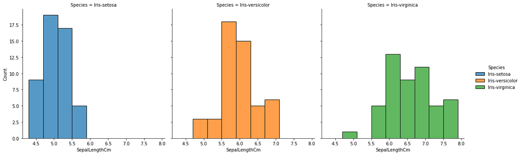

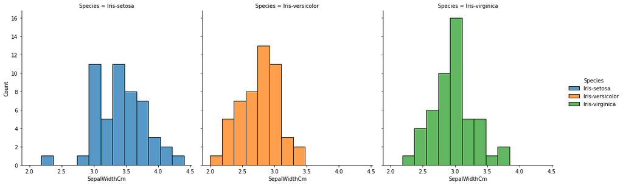

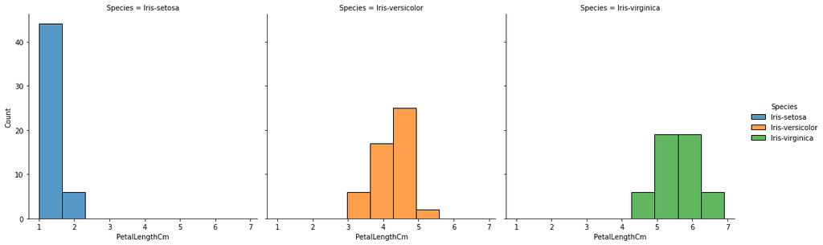

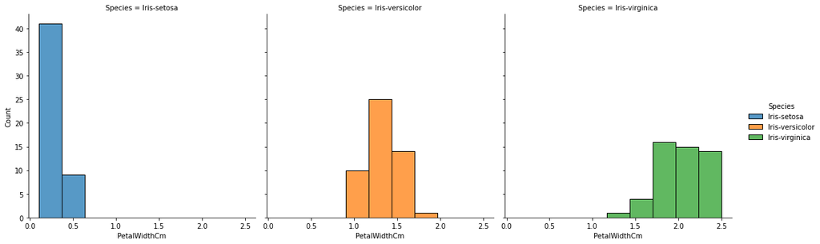

```python
# Distribution plot of each feature per target class
sns.displot(data=iris, x='SepalLengthCm', hue='Species', col='Species')
sns.displot(data=iris, x='SepalWidthCm', hue='Species', col='Species')
sns.displot(data=iris, x='PetalLengthCm', hue='Species', col='Species')
sns.displot(data=iris, x='PetalWidthCm', hue='Species', col='Species');
```

Distribution plot of features (variables), Sepal Length, Sepal Width, Petal Length and Petal Width per target (response) class, Species, Iris-setosa, Iris-versicolor, Iris-virginica.

###### 3.2.3 Boxplots

###### 3.2.3.1 Boxplot of features with matplotlib

```python
# Drop Id column
iris = iris.drop(['Id'], axis=1)
```

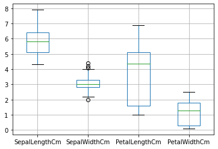

```python
# Boxplot of features with matplotlib
iris.boxplot();
```

Matplotlib Box plot of features (variables), Sepal Length, Sepal Width, Petal Length and Petal Width.

###### 3.2.3.2 Boxplot of features with seaborn

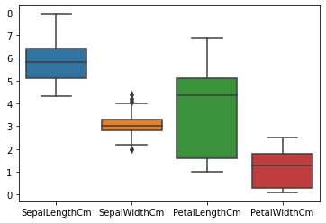

```python
# Boxplot of features with seaborn
sns.boxplot(data=iris);
```

Seaborn Box plot of features (variables), Sepal Length, Sepal Width, Petal Length and Petal Width.

###### 3.2.4 Violinplots

###### 3.2.4.1 Violinplot of features with matplotlib

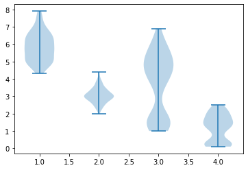

```python
# Violinplot of features with matplotlib
plt.violinplot(iris.iloc[:, 0:4]);
```

Matplotlib Violin plot of features (variables), Sepal Length, Sepal Width, Petal Length and Petal Width.

###### 3.2.4.2 Violoinplot of features with seaborn

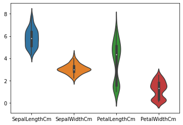

```python
# Violoinplot of features with seaborn
sns.violinplot(data=iris);
```

Seaborn Violin plot of features (variables), Sepal Length, Sepal Width, Petal Length and Petal Width.

###### 3.2.5 Kernel Density Estimator

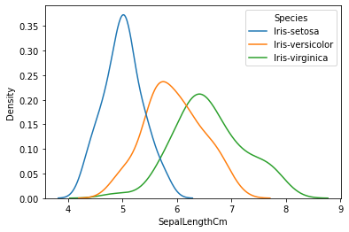

```python
# KDE of SepalLengthCm feature
sns.kdeplot(data=iris, x='SepalLengthCm', hue='Species');
```

Kernel Density Estimator of Sepal Length feature per target classes, Iris-setosa, Iris-versicolor, Iris-virginica.

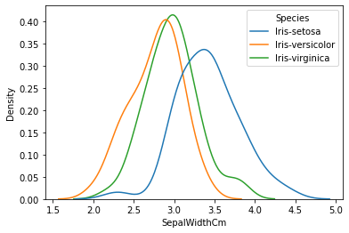

```python
# KDE of SepalWidthCm feature
sns.kdeplot(data=iris, x='SepalWidthCm', hue='Species');
```

Kernel Density Estimator of Sepal Width feature per target classes, Iris-setosa, Iris-versicolor, Iris-virginica.

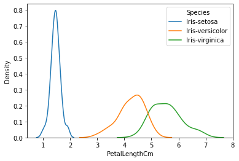

```python
# KDE of PetalLengthCm feature
sns.kdeplot(data=iris, x='PetalLengthCm', hue='Species');
```

Kernel Density Estimator of Petal Length feature per target classes, Iris-setosa, Iris-versicolor, Iris-virginica.

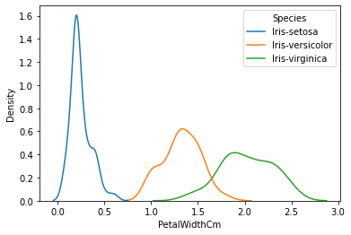

```python
# KDE of PetalWidthCm feature
sns.kdeplot(data=iris, x='PetalWidthCm', hue='Species');
```

Kernel Density Estimator of Petal Width feature per target classes, Iris-setosa, Iris-versicolor, Iris-virginica.

###### 3.2.6 Relational plot

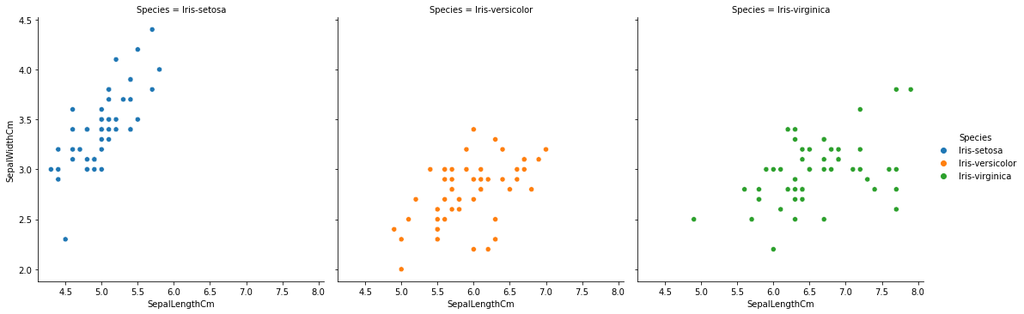

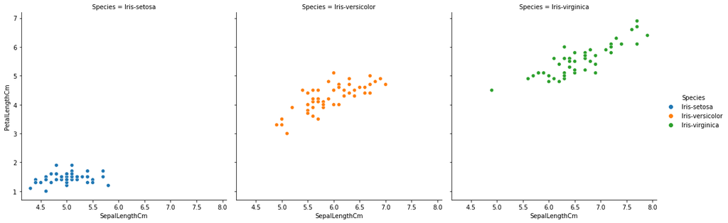

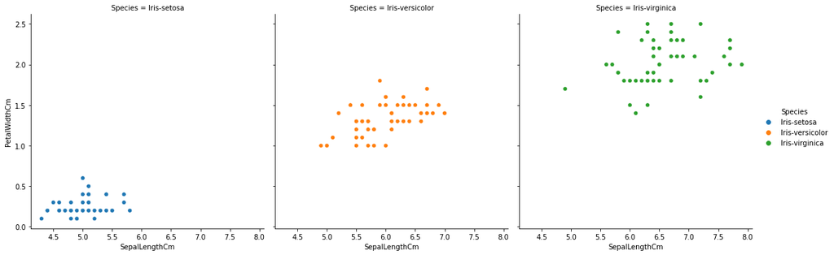

```python
# Relational plot SepalLengthCm vs the other three features per target

sns.relplot(
    data=iris, x='SepalLengthCm', y='SepalWidthCm',
    col='Species', hue='Species'
);

sns.relplot(
    data=iris, x='SepalLengthCm', y='PetalLengthCm',
    col='Species', hue='Species'
);

sns.relplot(
    data=iris, x='SepalLengthCm', y='PetalWidthCm',
    col='Species', hue='Species'
);
```

Relational plot of Sepal Length feature per target classes, Iris-setosa, Iris-versicolor, Iris-virginica.

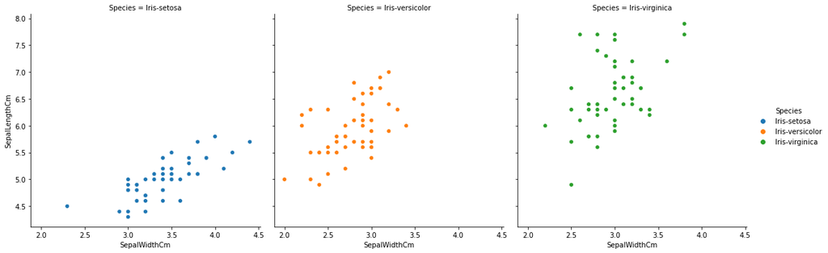

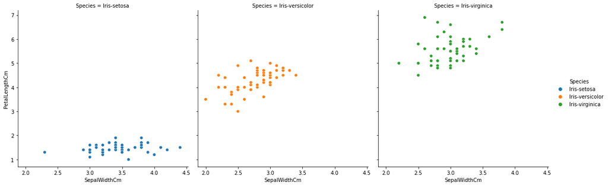

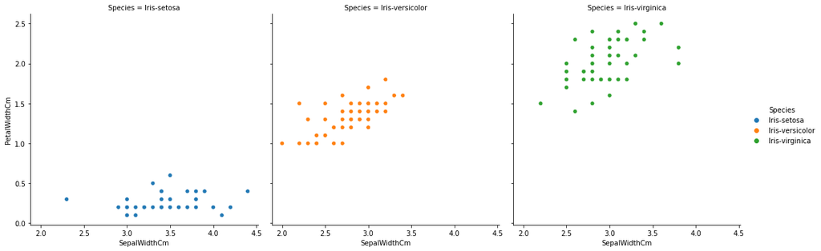

```python
# Relational plot SepalWidthCm vs the other three features per target

sns.relplot(
    data=iris, x='SepalWidthCm', y='SepalLengthCm',
    col='Species', hue='Species'
);

sns.relplot(
    data=iris, x='SepalWidthCm', y='PetalLengthCm',
    col='Species', hue='Species'
);

sns.relplot(
    data=iris, x='SepalWidthCm', y='PetalWidthCm',
    col='Species', hue='Species'
);
```

Relational plot of Sepal Width feature per target classes, Iris-setosa, Iris-versicolor, Iris-virginica.

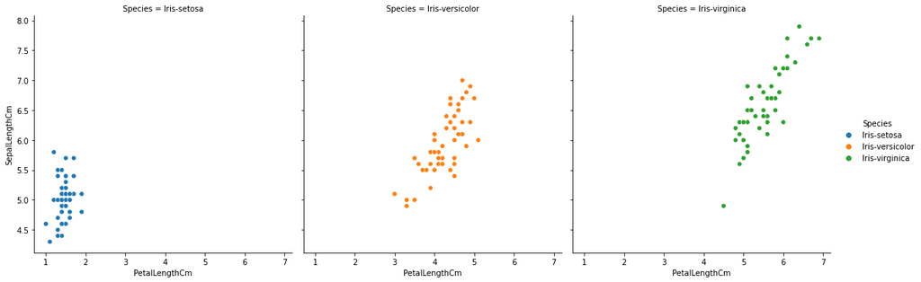

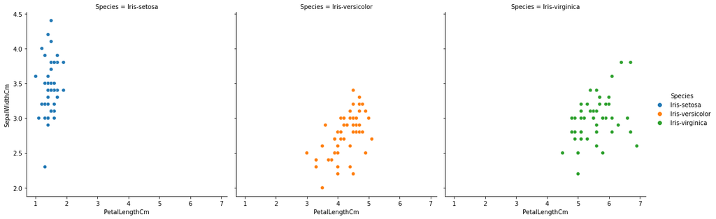

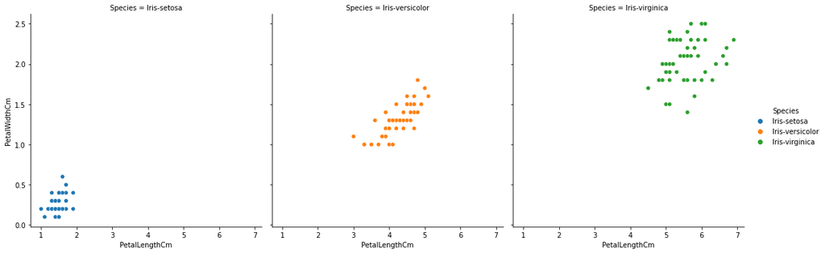

```python
# Relational plot PetalLengthCm vs the other three features per target

sns.relplot(
    data=iris, x='PetalLengthCm', y='SepalLengthCm',
    col='Species', hue='Species'
);

sns.relplot(
    data=iris, x='PetalLengthCm', y='SepalWidthCm',
    col='Species', hue='Species'
);

sns.relplot(
    data=iris, x='PetalLengthCm', y='PetalWidthCm',
    col='Species', hue='Species'
);
```

Relational plot of Petal Length feature per target classes, Iris-setosa, Iris-versicolor, Iris-virginica.

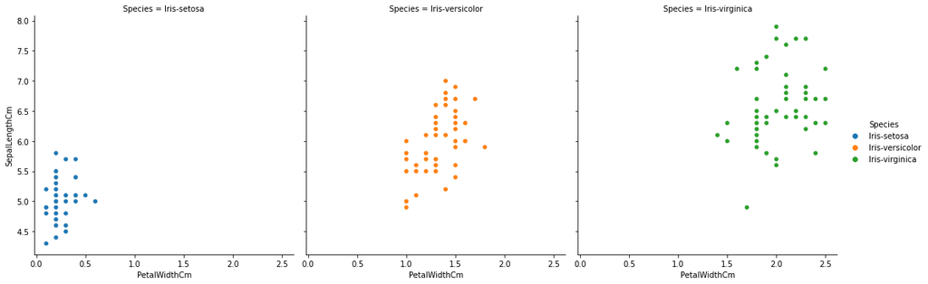

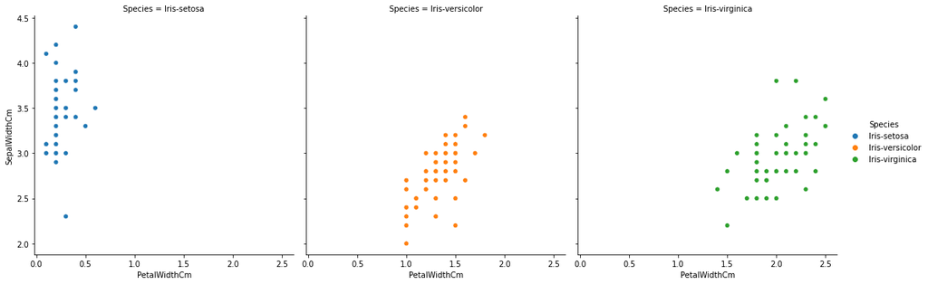

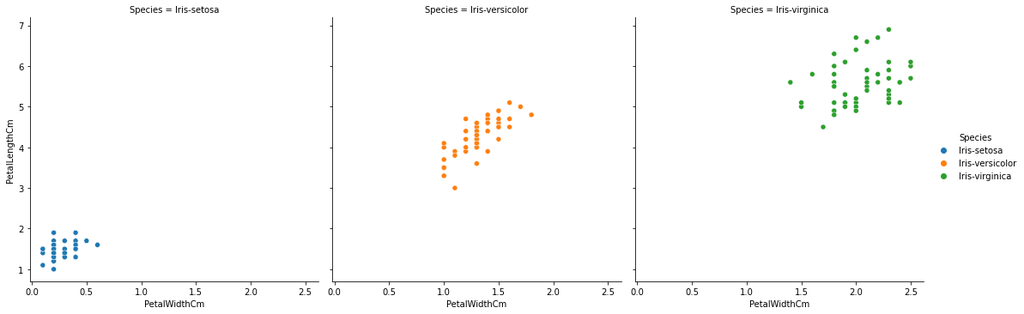

```python
# Relational plot PetalWidthCm vs the other three features per target

sns.relplot(
    data=iris, x='PetalWidthCm', y='SepalLengthCm',
    col='Species', hue='Species'
);

sns.relplot(
    data=iris, x='PetalWidthCm', y='SepalWidthCm',
    col='Species', hue='Species'
);

sns.relplot(
    data=iris, x='PetalWidthCm', y='PetalLengthCm',
    col='Species', hue='Species'
);
```

Relational plot of Petal Width feature per target classes, Iris-setosa, Iris-versicolor, Iris-virginica.

###### 3.2.7 Pairplot

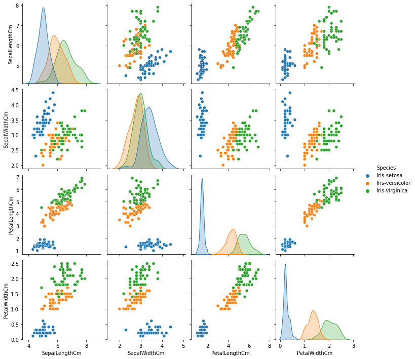

```python
# KDEs (diagonal) and scatterplots (off-diagonals) of features by target
sns.pairplot(iris, hue="Species");
```

Pair plot of features (variables), Sepal Length, Sepal Width, Petal Length and Petal Width per target (response) class, Species, Iris-setosa, Iris-versicolor, Iris-virginica. In diagonal axes Kernel Density Estimator of each feature against itself. In off-diagonal axes Scatter plot of each feature against each other.

###### 4. Correlation

###### 4.1 Correlation table and matrix with matplotlib

```
               SepalLengthCm  SepalWidthCm  PetalLengthCm  PetalWidthCm
SepalLengthCm       1.000000     -0.109369       0.871754      0.817954
SepalWidthCm       -0.109369      1.000000      -0.420516     -0.356544
PetalLengthCm       0.871754     -0.420516       1.000000      0.962757
PetalWidthCm        0.817954     -0.356544       0.962757      1.000000
```

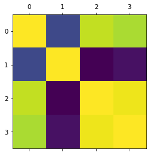

```python
# Correlation table and matrix with matplotlib
corr = iris.corr()
print(corr)
plt.matshow(iris.corr());
```

Matplotlib Correlation matrix of features (variables), Sepal Length, Sepal Width, Petal Length and Petal Width.

###### 4.1 Correlation matix with seaborn

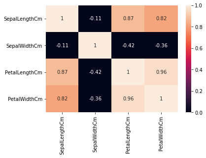

```python
# Correlation matix with seaborn
sns.heatmap(corr, vmin=0, vmax=1, annot=True);
```

Seaborn Correlation matrix of features (variables), Sepal Length, Sepal Width, Petal Length and Petal Width.

###### 5. Conclusion

In consideration of the Iris flower data set, this EDA uses tables to have a glimpse of the data table, information of variables (features and target) and statistical summaries of the data, and the visualizations histogram, box plot, violin plot, kernel density estimator, scatter plot and heat map to acknowledge the relationship between variables.

When possible, tables or visualizations are implemented in more than one package in order to compare and/or contrast, among other attributes, their functionality and performance, and, in this way, to prove which one offers a better user experience according to the user's interests.

As it was said in the introduction, usually EDA is developed by means of tables and visualizations. Choosing between one or another means of data representation depends on criteria like the kind of information that is useful to observe. If it's useful to look up particular information, like individual values or detailed summaries, tables are indicated, on the contrary, when it's useful to look up general information, like patterns, trends, exceptions, visualizations are the indicated. This EDA's guiding principle is precise to arrange the data set's main information by means of tables and its variables' behavior by means of visualizations.

Besides any criterion to choose between data representation means in an EDA, it seems that for correlations analysis both tables and visualizations are suitable. The former gives the exact values at which variables interact, while the latter gives the perspective of the whole variables' interaction. On purpose of correlation analysis, it'd better say that it may be or not part of an EDA.

This project about an EDA on the Iris flower data set is based in a judgement on the minimal tables and visualizations that this data set should have, however, the quantity of other data representation possible.